# ADP05-01

#### 데이터 분할

```r
credit.df <- read.csv("C:/Users/이찬솔/Desktop/숭실/R/ADP/실기/PART 05 실습용 데이터/credit_final.csv", header = T, sep = ",")
set.seed(1111)
idx <- sample(3, nrow(credit.df), replace = T, prob = c(0.5, 0.3, 0.2))
train <- credit.df[idx == 1,] ; test <- credit.df[idx == 2,] ; val <- credit.df[idx == 3,]
dim(train) ; dim(test) ; dim(val)
```

```
## [1] 483  21
```

```
## [1] 293  21
```

```
## [1] 224  21
```

- createDataPartition

```r
library(caret)
```

```r
part<-createDataPartition(credit.df$credit.rating,
                          times=1, # 생성할 데이터 분할은 1개로 지정
                          p=0.7) # 훈련데이터를 70%로 설정

parts <- as.vector(part$Resample1) # 훈련데이터 인덱스
train <- credit.df[parts,] ; test <- credit.df[-parts,]
nrow(train) ; nrow(test)
```

```
## [1] 700
```

```
## [1] 300
```

#### 성과분석

confusionMatrix(예측값, 실제값) - 예측값과 실제값 데이터 모두 factor형

```r
predicted <- factor(c(1,0,0,1,1,1,0,0,0,1,1,1))
actual <- factor(c(1,0,0,1,1,0,1,1,0,1,1,1))
confusionMatrix(predicted, actual)
```

```
## Confusion Matrix and Statistics
##
##           Reference
## Prediction 0 1
##          0 3 2
##          1 1 6
##
##                Accuracy : 0.75
##                  95% CI : (0.4281, 0.9451)
##     No Information Rate : 0.6667
##     P-Value [Acc > NIR] : 0.3931
##
##                   Kappa : 0.4706
##
##  Mcnemar's Test P-Value : 1.0000
##
##             Sensitivity : 0.7500
##             Specificity : 0.7500
##          Pos Pred Value : 0.6000
##          Neg Pred Value : 0.8571
##              Prevalence : 0.3333
##          Detection Rate : 0.2500
##    Detection Prevalence : 0.4167
##       Balanced Accuracy : 0.7500
##
##        'Positive' Class : 0
##
```

#### 분류 분석

###### 로지스틱 회귀분석

```r
credit <- read.csv("C:/Users/이찬솔/Desktop/숭실/R/ADP/실기/PART 05 실습용 데이터/credit_final.csv", header = T, sep = ",")
credit$credit.rating <- as.factor(credit$credit.rating)
set.seed(123)
idx <- sample(1:nrow(credit), nrow(credit)*0.7, replace = FALSE)
train <- credit[idx,] ; test <- credit[-idx,]
dim(train) ; dim(test)
```

```
## [1] 700  21
```

```
## [1] 300  21
```

```r
logistic <- glm(credit.rating ~ ., data = train,
                family = binomial(link = "logit"))
summary(logistic)
```

```
##
## Call:
## glm(formula = credit.rating ~ ., family = binomial(link = "logit"),
##     data = train)
##
## Deviance Residuals:
##     Min       1Q   Median       3Q      Max
## -2.4763  -0.7811   0.4133   0.7147   2.0078
##
## Coefficients:
##                                  Estimate Std. Error z value Pr(>|z|)
## (Intercept)                    -4.249e+00  1.419e+00  -2.994 0.002754 **
## account.balance                 8.687e-01  1.224e-01   7.096 1.28e-12 ***
## credit.duration.months         -2.145e-02  1.072e-02  -2.000 0.045501 *
## previous.credit.payment.status  5.635e-01  1.897e-01   2.971 0.002973 **
## credit.purpose                 -4.133e-01  1.111e-01  -3.721 0.000198 ***
## credit.amount                  -7.722e-05  5.011e-05  -1.541 0.123341
## savings                         3.531e-01  9.689e-02   3.645 0.000268 ***
## employment.duration             1.311e-01  1.003e-01   1.307 0.191067
## installment.rate               -1.986e-01  1.002e-01  -1.983 0.047357 *
## marital.status                  1.724e-01  9.722e-02   1.774 0.076139 .
## guarantor                       6.995e-01  3.548e-01   1.971 0.048679 *
## residence.duration             -2.940e-02  9.385e-02  -0.313 0.754063
## current.assets                 -2.963e-01  1.075e-01  -2.757 0.005828 **
## age                             1.587e-02  1.009e-02   1.573 0.115623
## other.credits                   4.845e-01  2.480e-01   1.953 0.050801 .
## apartment.type                  4.437e-01  2.061e-01   2.152 0.031369 *
## bank.credits                   -2.773e-01  2.391e-01  -1.160 0.246186
## occupation                     -1.608e-01  1.672e-01  -0.962 0.335964
## dependents                     -1.087e-01  2.831e-01  -0.384 0.700955
## telephone                       4.068e-01  2.257e-01   1.803 0.071425 .
## foreign.worker                  1.433e+00  8.141e-01   1.760 0.078390 .
## ---
## Signif. codes:  0 '***' 0.001 '**' 0.01 '*' 0.05 '.' 0.1 ' ' 1
##
## (Dispersion parameter for binomial family taken to be 1)
##
##     Null deviance: 846.57  on 699  degrees of freedom
## Residual deviance: 651.47  on 679  degrees of freedom
## AIC: 693.47
##
## Number of Fisher Scoring iterations: 5
```

```r
step.logistic<-step(glm(credit.rating ~ ., data = train, family = "binomial"),
                    scope = list(lower = ~ 1, upper = ~ .),
                    direction = "backward")
```

```r
summary(step.logistic)
```

```
##
## Call:
## glm(formula = credit.rating ~ account.balance + credit.duration.months +
##     previous.credit.payment.status + credit.purpose + credit.amount +
##     savings + installment.rate + marital.status + guarantor +
##     current.assets + age + other.credits + apartment.type + telephone +
##     foreign.worker, family = "binomial", data = train)
##
## Deviance Residuals:
##     Min       1Q   Median       3Q      Max
## -2.4495  -0.7921   0.4276   0.7235   1.9356
##
## Coefficients:
##                                  Estimate Std. Error z value Pr(>|z|)
## (Intercept)                    -4.825e+00  1.322e+00  -3.648 0.000264 ***
## account.balance                 8.722e-01  1.214e-01   7.186 6.67e-13 ***
## credit.duration.months         -2.029e-02  1.061e-02  -1.913 0.055731 .
## previous.credit.payment.status  4.799e-01  1.664e-01   2.884 0.003924 **
## credit.purpose                 -4.115e-01  1.094e-01  -3.762 0.000169 ***
## credit.amount                  -8.530e-05  4.927e-05  -1.731 0.083405 .
## savings                         3.728e-01  9.588e-02   3.888 0.000101 ***
## installment.rate               -2.083e-01  9.886e-02  -2.107 0.035113 *
## marital.status                  1.854e-01  9.473e-02   1.957 0.050388 .
## guarantor                       6.590e-01  3.514e-01   1.876 0.060722 .
## current.assets                 -3.104e-01  1.057e-01  -2.937 0.003318 **
## age                             1.801e-02  9.505e-03   1.894 0.058164 .
## other.credits                   5.082e-01  2.450e-01   2.074 0.038035 *
## apartment.type                  4.501e-01  2.043e-01   2.203 0.027613 *
## telephone                       3.468e-01  2.139e-01   1.621 0.105004
## foreign.worker                  1.449e+00  8.129e-01   1.782 0.074675 .
## ---
## Signif. codes:  0 '***' 0.001 '**' 0.01 '*' 0.05 '.' 0.1 ' ' 1
##
## (Dispersion parameter for binomial family taken to be 1)
##
##     Null deviance: 846.57  on 699  degrees of freedom
## Residual deviance: 655.22  on 684  degrees of freedom
## AIC: 687.22
##
## Number of Fisher Scoring iterations: 5
```

###### predict(model, newdata, type, …)

- type : 예측 결과의 유형 지정 (link : 로그오즈값 / class : 범주형(factor) 값 / response : 0 ~ 1 확률값)

```r
pred <- predict(step.logistic, newdata = test,
                type = "response")
pred1 <- as.data.frame(pred)
pred1$grade <- ifelse(pred1$pred < 0.5, 0, 1)
confusionMatrix(as.factor(pred1$grade), test$credit.rating,
                positive = '1') # 1값을 Positive로 인식
```

```
## Confusion Matrix and Statistics
##
##           Reference
## Prediction   0   1
##          0  45  20
##          1  50 185
##
##                Accuracy : 0.7667
##                  95% CI : (0.7146, 0.8134)
##     No Information Rate : 0.6833
##     P-Value [Acc > NIR] : 0.0009172
##
##                   Kappa : 0.4109
##
##  Mcnemar's Test P-Value : 0.0005279
##
##             Sensitivity : 0.9024
##             Specificity : 0.4737
##          Pos Pred Value : 0.7872
##          Neg Pred Value : 0.6923
##              Prevalence : 0.6833
##          Detection Rate : 0.6167
##    Detection Prevalence : 0.7833
##       Balanced Accuracy : 0.6881
##
##        'Positive' Class : 1
##
```

##### ROC곡선

- prediction(예측값, 실제값), 예측값과 실제값에 들어갈 데이터는 numeric
- performance(prediction객체, “tpr”, “fpr”)
- performance(prediction객체, “auc”)

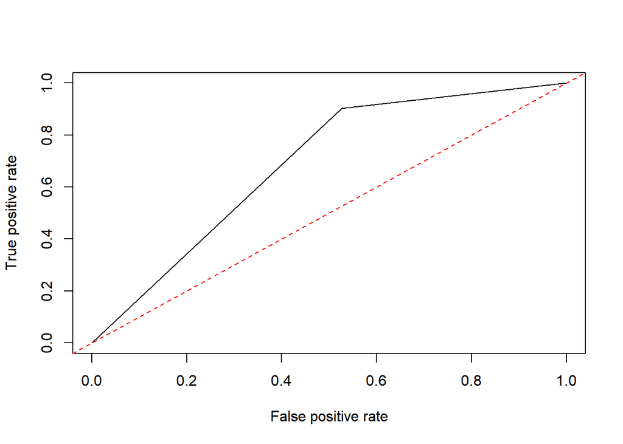

```r
library(ROCR)
roc <- prediction(pred1$grade, test$credit.rating)
rocp <- performance(roc, "tpr", "fpr")
plot(rocp) ; abline(a=0, b=1, lty = 2, col = "red")
```

- AUC값

```r
auc <- performance(roc, "auc") ; auc <- unlist(auc@y.values)
```

###### 다항 로지스틱 회귀분석

- multinom(formula, data)

```r
library(nnet)
```

```r
idx <- sample(1:nrow(iris), nrow(iris)*0.7, replace = FALSE)
iris.train <- iris[idx,] ; iris.test <- iris[-idx,]
mul.iris <- multinom(Species ~ ., iris.train)
pred.mul <- predict(mul.iris, newdata = iris.test)
confusionMatrix(pred.mul, iris.test$Species)
```

```
## Confusion Matrix and Statistics
##
##             Reference
## Prediction   setosa versicolor virginica
##   setosa         15          0         0
##   versicolor      0         10         0
##   virginica       0          0        20
##
## Overall Statistics
##
##                Accuracy : 1
##                  95% CI : (0.9213, 1)
##     No Information Rate : 0.4444
##     P-Value [Acc > NIR] : < 2.2e-16
##
##                   Kappa : 1
##
##  Mcnemar's Test P-Value : NA
##
## Statistics by Class:
##
##                      Class: setosa Class: versicolor Class: virginica
## Sensitivity                 1.0000            1.0000           1.0000
## Specificity                 1.0000            1.0000           1.0000
## Pos Pred Value              1.0000            1.0000           1.0000
## Neg Pred Value              1.0000            1.0000           1.0000
## Prevalence                  0.3333            0.2222           0.4444
## Detection Rate              0.3333            0.2222           0.4444
## Detection Prevalence        0.3333            0.2222           0.4444
## Balanced Accuracy           1.0000            1.0000           1.0000
```

#### 의사결정나무

- 성장 -> 가지치기 -> 타당성 평가 -> 해석 및 예측
- 분리 규칙 이산형 : 카이제곱 통계량 p값, 지니지수, 엔트로피 지수 연속형 : 분산분석 F통계량, 분산의 감소량
- 정지규칙 : 나무의 깊이, 끝마디의 레코드 수의 최소 개수
- 가지치기 : 비용 복잡도 가지치기, 과적합 방지
- 타당성평가 ; 이익도표, 위험도표
- cART : (범주형 : 지니지수 / 연속형 : 분산)
- C4.5 / C5.0 : 다지분리(입력변수의 범주 만큼 분리가 발생), 엔트로피지수 사용
- CAHID : 가지치기X, 입력변수가 반드시 범주형, 카이제곱 통계량 사용
- tree : 엔트로피 지수 사용 / ctree : 가지치기X / rpart : CART

###### rpart(formula, data, method, control = rpart.control(), …)

- method : 나무 종류 선정 (anova, poisson, exp 등이 존재)
- control : 옵션설정

```r
library(rpart)
library(rpart.plot)
```

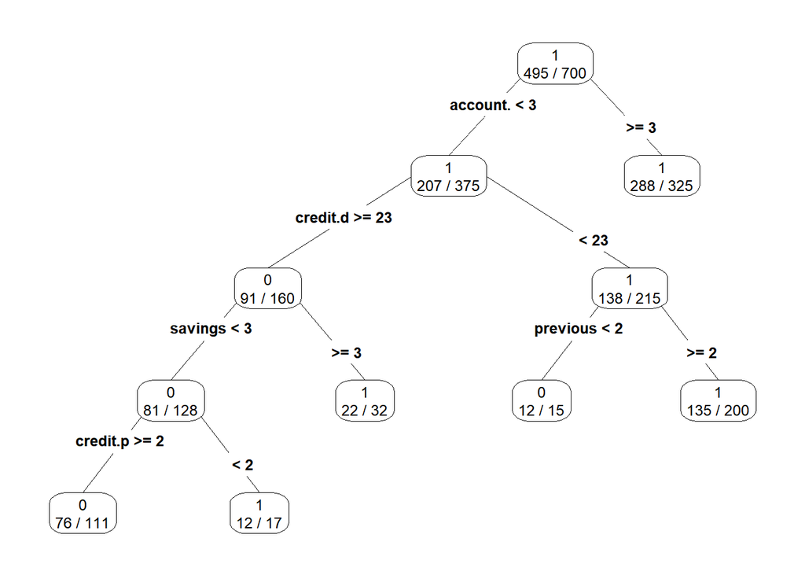

```r
dt.model <- rpart(credit.rating ~ .,
                  method = "class",
                  data = train,
                  control = rpart.control(maxdepth = 5,    #의사결정나무의 최대 깊이는 5개까지
                                          minsplit = 15))  #노드에서 최소 관측치는 15개 이상
prp(dt.model, type = 4, extra = 2)
```

- 교차타당성 오차 제공

```r
dt.model$cptable
```

```
##           CP nsplit rel error    xerror       xstd
## 1 0.05365854      0 1.0000000 1.0000000 0.05873225
## 2 0.04390244      3 0.8341463 0.9853659 0.05847732
## 3 0.03414634      4 0.7902439 0.9804878 0.05839093
## 4 0.01000000      5 0.7560976 0.9756098 0.05830383
```

- nsplit : 분할 횟수
- xerror : 해당 CP에서 CV했을 때 오류율
- xstd : 해당 CP에서 CV했을 떄 편차
- cptable에서 xerror가 가장 낮은 split 개와 CP선택

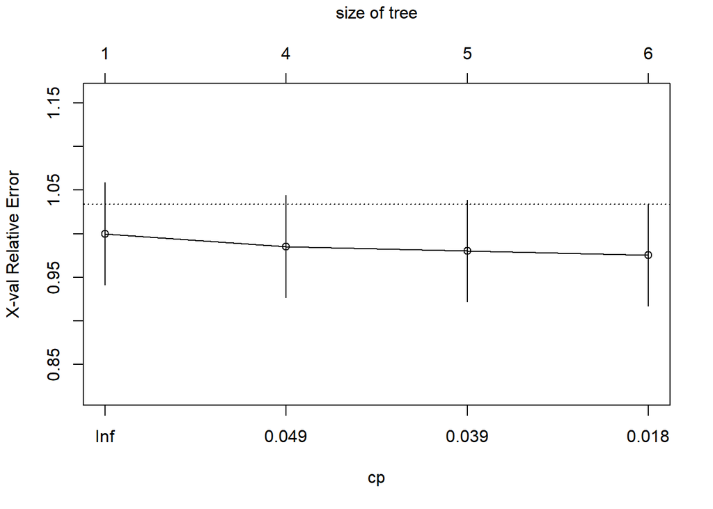

```r
opt <- which.min(dt.model$cptable[,"xerror"])
cp <- dt.model$cptable[opt,"CP"]
prune.c <- prune(dt.model, cp=cp)
plotcp(dt.model)
```

```r
pred.dt <- predict(dt.model, newdata = test, type = "class")
confusionMatrix(pred.dt, as.factor(test$credit.rating), positive = '1')
```

```
## Confusion Matrix and Statistics
##
##           Reference
## Prediction   0   1
##          0  42  21
##          1  53 184
##
##                Accuracy : 0.7533
##                  95% CI : (0.7005, 0.8011)
##     No Information Rate : 0.6833
##     P-Value [Acc > NIR] : 0.0047614
##
##                   Kappa : 0.3734
##
##  Mcnemar's Test P-Value : 0.0003137
##
##             Sensitivity : 0.8976
##             Specificity : 0.4421
##          Pos Pred Value : 0.7764
##          Neg Pred Value : 0.6667
##              Prevalence : 0.6833
##          Detection Rate : 0.6133
##    Detection Prevalence : 0.7900
##       Balanced Accuracy : 0.6698
##
##        'Positive' Class : 1
##
```

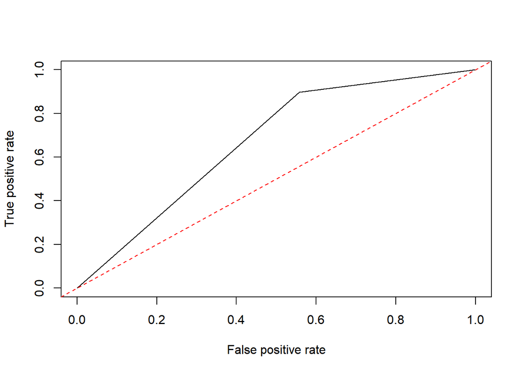

```r
dt.roc <- prediction(as.numeric(pred.dt), as.numeric(test$credit.rating))
dt.perf <- performance(dt.roc, "tpr", "fpr") ; dt.auc <- performance(dt.roc, "auc")
plot(dt.perf) ; abline(0, 1, lty = 2, col = "red")
```

```r
(auc <- unlist(dt.auc@y.values))
```

```
## [1] 0.6698331
```

#### 앙상블

##### 배깅

- 여러 개의 붓스트랩 자료를 생성하고, 각 붓스트랩 자료에 예측모형을 만든 후 결합

bagging(formula, data, mfinal, control = , …) - mfinal : 반복 수 또는 사용 트리 수 - control : 옵션 설정

```r
library(adabag)
idx <- sample(1:nrow(credit), nrow(credit)*0.7, replace = FALSE)
train <- credit[idx,] ; test <- credit[-idx,]
```

```r
bag <- bagging(credit.rating ~ ., data = train, mfinal = 15)
names(bag)
```

```
## [1] "formula"    "trees"      "votes"      "prob"       "class"
## [6] "samples"    "importance" "terms"      "call"
```

- trees : 생성된 나무의 수
- votes : 투표 진행
- class : 배깅을 활용해 각 행의 분류를 예측한 결과
- samples : 각 나무에 사용된 붓스트랩 데이터의 레코드 번호
- importance : 변수의 상대적인 중요도 (지니지수의 gain)

```r
pred.bg <- predict(bag, newdata = test, type = "class")
confusionMatrix(as.factor(pred.bg$class), test$credit.rating, positive = '1')
```

```
## Confusion Matrix and Statistics
##
##           Reference
## Prediction   0   1
##          0  40  33
##          1  49 178
##
##                Accuracy : 0.7267
##                  95% CI : (0.6725, 0.7763)
##     No Information Rate : 0.7033
##     P-Value [Acc > NIR] : 0.20647
##
##                   Kappa : 0.3091
##
##  Mcnemar's Test P-Value : 0.09763
##
##             Sensitivity : 0.8436
##             Specificity : 0.4494
##          Pos Pred Value : 0.7841
##          Neg Pred Value : 0.5479
##              Prevalence : 0.7033
##          Detection Rate : 0.5933
##    Detection Prevalence : 0.7567
##       Balanced Accuracy : 0.6465
##
##        'Positive' Class : 1
##
```

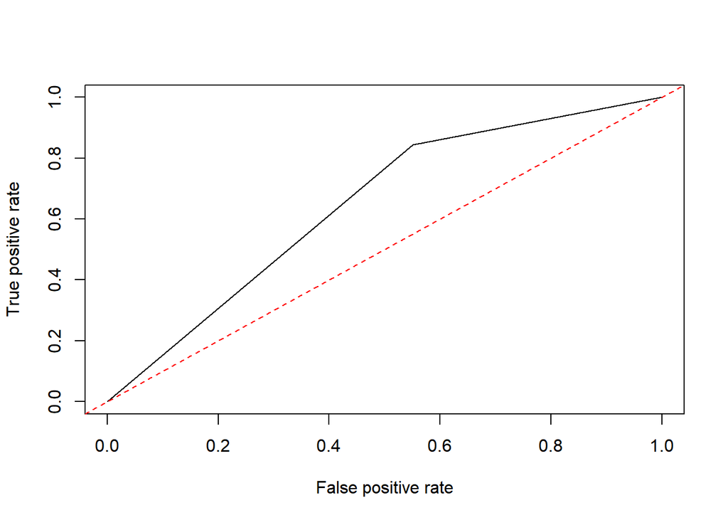

```r
bg.roc <- prediction(as.numeric(pred.bg$class), as.numeric(test$credit.rating))
bg.perf <- performance(bg.roc, "tpr", "fpr") ; bg.auc <- performance(bg.roc, "auc")
plot(bg.perf) ; abline(0, 1, lty = 2, col = "red")
```

```r
(auc <- unlist(bg.auc@y.values))
```

```
## [1] 0.64652
```

##### 부스팅

- 약한 모형들을 결합하여 강한 예측모형을 만듬
- 랜덤 분류기보다 조금 더 좋은 분류기 n개에 각각 가중치를 설정하고, n개의 분류기를 결합하여 최종 분류기를 만드는 방법을 제안
- 훈련오차를 빨리, 쉽게 줄일 수 잇고, 배깅보다 뛰어난 성능

boosting(formula, data, boos, mfinal, control = , …) - boos : 샘플의 가중치 여부 (TRUE : 붓스트랩 샘플의 iteration에 대한 관찰값들에 대해 가중치 적용 / FALSE : 모든 관측치에 동일한 가중치 부여) - mfinal : 반복 수 또는 사용할 트리의 수 - contril : 옵션 설정

```r
boost <- boosting(credit.rating ~ ., data = train,
                  boos = T, mfinal = 80)
names(boost)
```

```
## [1] "formula"    "trees"      "weights"    "votes"      "prob"
## [6] "class"      "importance" "terms"      "call"
```

- trees : 부스팅을 통해 생성된 나무
- weights : 각 나무에 부여된 가중치 값
- votes : 투표 진행
- class : 부스팅을 활용해 각 행의 분류를 예측한 것
- importance : 변수의 상대적 중요도 (지니지수의 gain)

```r
pred.boos <- predict(boost, newdata = test, type = "class")
confusionMatrix(as.factor(pred.boos$class), test$credit.rating, positive = '1')
```

```
## Confusion Matrix and Statistics
##
##           Reference
## Prediction   0   1
##          0  44  35
##          1  45 176
##
##                Accuracy : 0.7333
##                  95% CI : (0.6795, 0.7825)
##     No Information Rate : 0.7033
##     P-Value [Acc > NIR] : 0.1410
##
##                   Kappa : 0.3395
##
##  Mcnemar's Test P-Value : 0.3143
##
##             Sensitivity : 0.8341
##             Specificity : 0.4944
##          Pos Pred Value : 0.7964
##          Neg Pred Value : 0.5570
##              Prevalence : 0.7033
##          Detection Rate : 0.5867
##    Detection Prevalence : 0.7367
##       Balanced Accuracy : 0.6643
##
##        'Positive' Class : 1
##
```

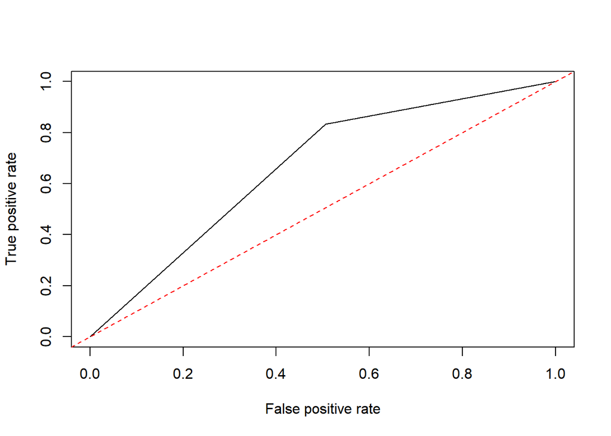

```r
boos.roc <- prediction(as.numeric(pred.boos$class), as.numeric(test$credit.rating))
boos.perf <- performance(boos.roc, "tpr", "fpr"); boos.auc <- performance(boos.roc, "auc")
plot(boos.perf); abline(0, 1, lty = 2, col = "red")
```

```r
(auc <- unlist(boos.auc@y.values))
```

```
## [1] 0.6642526
```

##### 랜덤포레스트

- 부스팅보다 더 많은 무작위성을 주어 약한 학습기들을 선형 결합하여 최종 학습기 만드는 방법

randomForest(formula, data, ntree, mtry, …) - ntree : 사용할 트리의 수 - mtry : 각 분할에서 랜덤으로 뽑힌 변수의 개수 (분류의 경우 sqrt(변수개수) / 회귀의 경우 (변수개수 / 3))

```r
library(randomForest)
```

```r
rf.model<-randomForest(credit.rating ~.,
                       data=train,
                       ntree=50, # 나무 50개 사용
                       mtry=sqrt(20), # 사용할 변수의 개수(classification이므로 sqrt(20)개)
                       importance=T) # 변수중요도 결과를 확인
rf.model
```

```
##
## Call:
##  randomForest(formula = credit.rating ~ ., data = train, ntree = 50,      mtry = sqrt(20), importance = T)
##                Type of random forest: classification
##                      Number of trees: 50
## No. of variables tried at each split: 4
##
##         OOB estimate of  error rate: 25.71%
## Confusion matrix:
##    0   1 class.error
## 0 97 114   0.5402844
## 1 66 423   0.1349693
```

```r
names(rf.model)
```

```
##  [1] "call"            "type"            "predicted"       "err.rate"
##  [5] "confusion"       "votes"           "oob.times"       "classes"
##  [9] "importance"      "importanceSD"    "localImportance" "proximity"
## [13] "ntree"           "mtry"            "forest"          "y"
## [17] "test"            "inbag"           "terms"
```

- predicted : OOB에 기초한 예측값 확인
- err.rate : 입력데이터 각각에 대한 예측 오류율 확인
- importance : 변수중요도

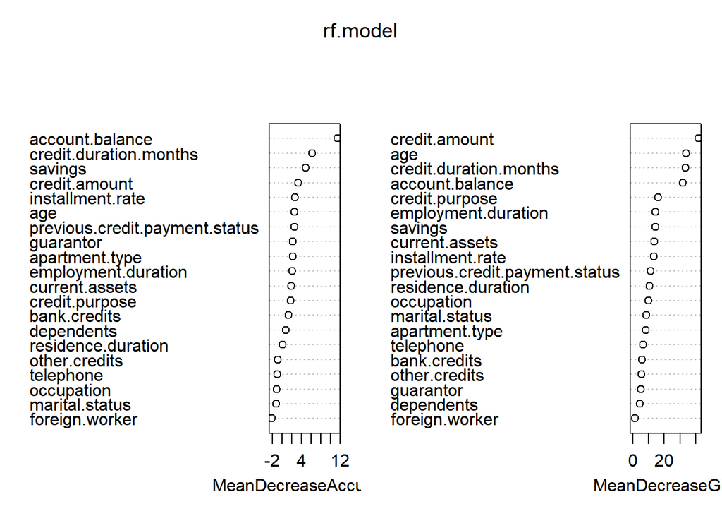

```r
varImpPlot(rf.model)
```

```r
pred.rf <- predict(rf.model, newdata = test, type = "class")
confusionMatrix(as.factor(pred.rf), as.factor(test$credit.rating), positive = '1')
```

```
## Confusion Matrix and Statistics
##
##           Reference
## Prediction   0   1
##          0  39  27
##          1  50 184
##
##                Accuracy : 0.7433
##                  95% CI : (0.69, 0.7918)
##     No Information Rate : 0.7033
##     P-Value [Acc > NIR] : 0.07159
##
##                   Kappa : 0.3353
##
##  Mcnemar's Test P-Value : 0.01217
##
##             Sensitivity : 0.8720
##             Specificity : 0.4382
##          Pos Pred Value : 0.7863
##          Neg Pred Value : 0.5909
##              Prevalence : 0.7033
##          Detection Rate : 0.6133
##    Detection Prevalence : 0.7800
##       Balanced Accuracy : 0.6551
##
##        'Positive' Class : 1
##
```

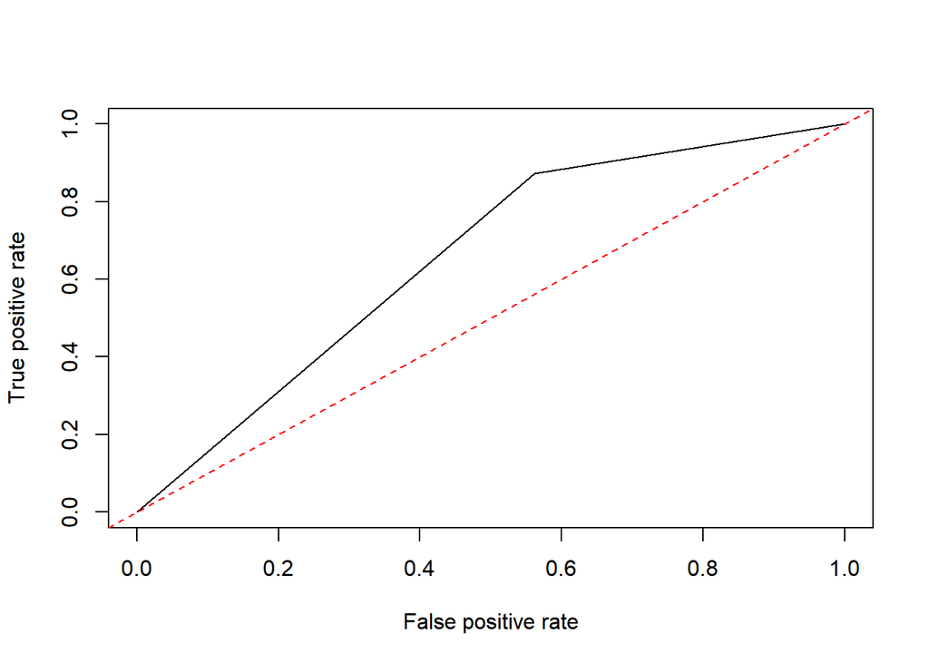

```r
rf.roc <- prediction(as.numeric(pred.rf), as.numeric(test$credit.rating))
rf.perf <- performance(rf.roc, "tpr", "fpr"); rf.auc <- performance(rf.roc, "auc")
plot(rf.perf) ; abline(0, 1, lty = 2, col = "red")
```

```r
(auc <- unlist(rf.auc@y.values))
```

```
## [1] 0.6551201
```

#### SVM

- 결정 초평면 : 각 그룹을 구분하는 분류자를 결정 초평면
- 서포트 벡터 : 초평면에 가장 가까이에 붙은 최전방 데이터 = 마진 : 서포트 벡터와 초평면 사이의 수직거리 = 초평면 : n차원의 공간보다 한 차원이 낮은 n-1차원의 하위공간
- 마진을 최대화 하는 초평면(최대 마진 초평면)을 찾아 분류와 회귀를 수행
- 비선형 분류에도 사용 (kernel trick)

svm(formula, data, kernel, gamma, cost, …) - kernel : 훈련과 예측에 사용되는 커널 (“kernel”, “linear”, “polynomial”, “sigmoid”) - gamma : 초평면의 기울기 - cost : 과적합을 막는 정도

tune.svm(formula, data, kernel, gamma, cost, …)

- 최적의 초 매개변수 탐색

```r
library(e1071)
```

```r
tune.svm(credit.rating ~ ., data = credit,
         gamma = 10^(-6:-1), cost = 10^(1:2))
```

```
##
## Parameter tuning of 'svm':
##
## - sampling method: 10-fold cross validation
##
## - best parameters:
##  gamma cost
##   0.01   10
##
## - best performance: 0.232
```

```r
svm.model <- svm(credit.rating ~ ., data = train, kernel = "radial",
                 gamma = 0.01, cost = 10)
summary(svm.model)
```

```
##
## Call:
## svm(formula = credit.rating ~ ., data = train, kernel = "radial",
##     gamma = 0.01, cost = 10)
##
##
## Parameters:
##    SVM-Type:  C-classification
##  SVM-Kernel:  radial
##        cost:  10
##
## Number of Support Vectors:  391
##
##  ( 209 182 )
##
##
## Number of Classes:  2
##
## Levels:
##  0 1
```

```r
pred.svm <- predict(svm.model, test, type = "class")
confusionMatrix(as.factor(pred.svm), test$credit.rating, positive = '1')
```

```
## Confusion Matrix and Statistics
##
##           Reference
## Prediction   0   1
##          0  43  25
##          1  46 186
##
##                Accuracy : 0.7633
##                  95% CI : (0.7111, 0.8103)
##     No Information Rate : 0.7033
##     P-Value [Acc > NIR] : 0.01223
##
##                   Kappa : 0.3914
##
##  Mcnemar's Test P-Value : 0.01762
##
##             Sensitivity : 0.8815
##             Specificity : 0.4831
##          Pos Pred Value : 0.8017
##          Neg Pred Value : 0.6324
##              Prevalence : 0.7033
##          Detection Rate : 0.6200
##    Detection Prevalence : 0.7733
##       Balanced Accuracy : 0.6823
##
##        'Positive' Class : 1
##
```

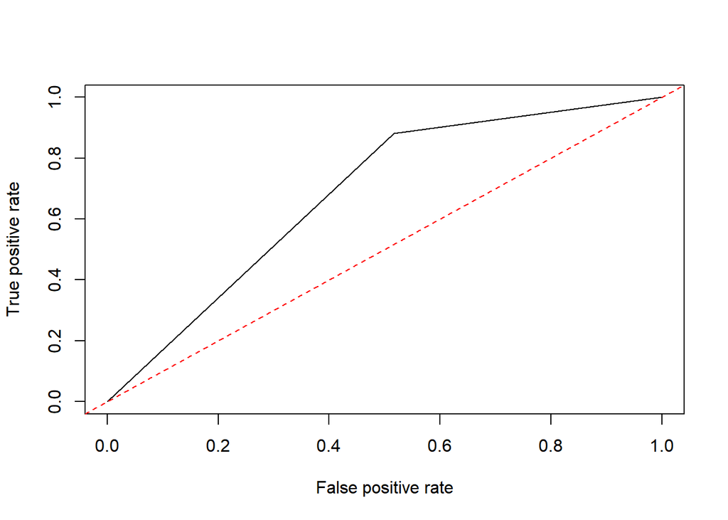

```r
svm.roc <- prediction(as.numeric(pred.svm), as.numeric(test$credit.rating))
svm.perf <- performance(svm.roc, "tpr", "fpr"); svm.auc <- performance(svm.roc, "auc")
plot(svm.perf) ; abline(0, 1, lty = 2, col = "red")
```

```r
(auc <- unlist(svm.auc@y.values))
```

```
## [1] 0.6823313
```

```r
tune <- tune.svm(Species ~ ., data = iris, gamma = 2^(-1:1), cost = 2^(2:4))
tune$best.parameters
tune$best.model

ind <- sample(1:nrow(iris), nrow(iris)*0.7, replace = FALSE)
iris.train <- iris[ind,] ; iris.test <- iris[-ind,]
svm.model2 <- svm(Species ~ ., data = iris.train, kernel = "radial", gamma = 0.5, cost = 4 )
pred.svm2 <- predict(svm.model2, newdata = iris.test, type = "class")

confusionMatrix(as.factor(pred.svm2), as.factor(iris.test$Species))
```

#### 나이브 베이즈

naiveBayes(formula, data, laplace = 0, …) - laplace : 라플라스 보정 여부

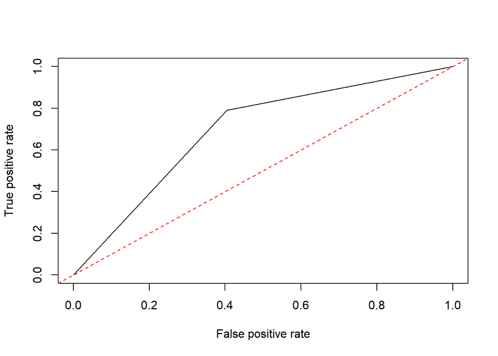

```r
nb.model <- naiveBayes(credit.rating ~ ., data = train)
pred.nb <- predict(nb.model, newdata = test, type = "class")
confusionMatrix(as.factor(pred.nb), as.factor(test$credit.rating), positive = '1')

nb.roc <- prediction(as.numeric(pred.nb), as.numeric(test$credit.rating))
nb.perf <- performance(nb.roc, "tpr", "fpr"); nb.auc <- performance(nb.roc, "auc")
plot(nb.perf) ; abline(0, 1, lty = 2, col = "red")
```

```r
(auc <- unlist(nb.auc@y.values))
```

#### KNN

- 일반적으로 K는 훈련 데이터 개수의 제곱근으로 설정

knn(train, test, cl, k, …) - cl : 훈련 데이터의 반응변수 - k : K값

```r
library(class)
```

```r
train.data <- train[, -1] ; test.data <- test[, -1] ; class <- train[, 1]
result <- numeric()
for (i in 3:22) {
  pred <- knn(train.data, test.data, class, k = i-2)
  result[i-2] = mean(pred == test$credit.rating)
}
result ; which.max(result)
```

```
##  [1] 0.6066667 0.5733333 0.6233333 0.6466667 0.6700000 0.7066667 0.6866667
##  [8] 0.6900000 0.7033333 0.6933333 0.7033333 0.6833333 0.6966667 0.6833333
## [15] 0.6833333 0.6966667 0.6933333 0.6933333 0.6966667 0.6966667
```

```
## [1] 6
```

#### ANN

- 계단함수 [0 / 1]
- 부호함수 [-1 / 1]
- 시그모이드 함수 [1 / (1+e^x)]
- relu 함수 [0 / x]
- 소프트맥스 : 표준화지수 함수, 출력값이 여러 개, 목표치가 다범주인 경우 각 범주에 속할 사후확률 제공

##### nnet

- 전통적인 역전파
- 전방 포워드 신경망 훈련
- 신경망 매개변수 : 엔트로피, SSE
- 소프트맥스 함수를 사용해 확률 형태로 변환, 과적합을 막기 위해 가중치 감소 제공

nnet(formula, data, size, maxit, decay) - size : 은닉 노드 개수 - maxit : 학습 반복횟수 - decay : 가중치 감소의 모수 (보통 5e-04)

```r
library(nnet)
```

```r
set.seed(1231)
nn.model <- nnet(credit.rating ~ ., data = train, size = 2,
                 maxit = 200, decay = 5e-04)
```

- 변수 중요도 파악 garson(mod_in)

```r
library(NeuralNetTools)
```

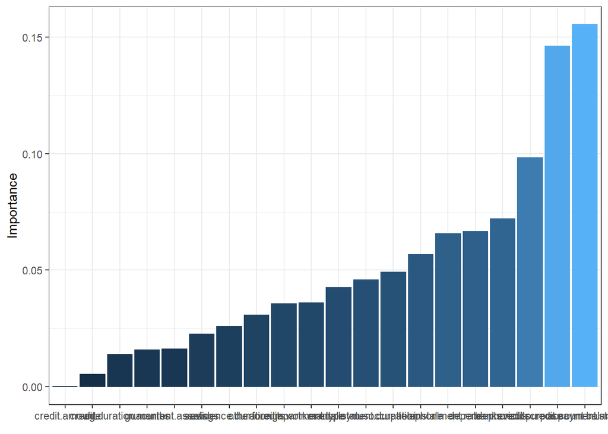

```r
garson(nn.model)
```

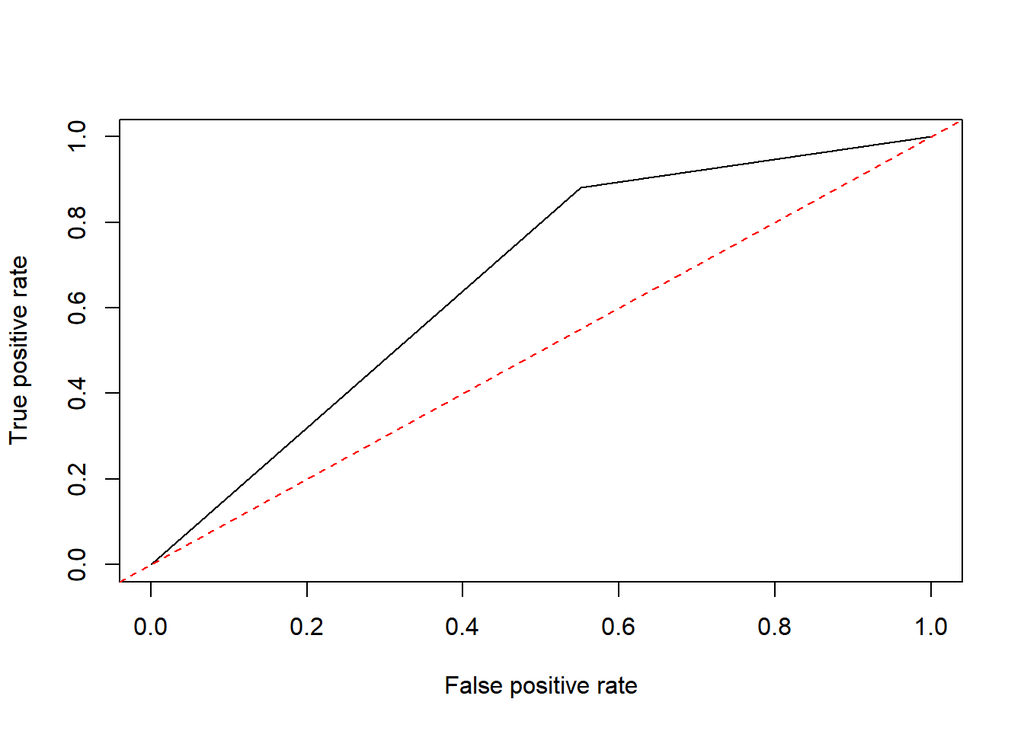

```r
pred.nn <- predict(nn.model, test, type = "class")
confusionMatrix(as.factor(pred.nn), as.factor(test$credit.rating), positive = '1')

nn.roc <- prediction(as.numeric(pred.nn), as.numeric(test$credit.rating))
nn.perf <- performance(nn.roc, "tpr", "fpr") ; nn.auc <- performance(nn.roc, "auc")
plot(nn.perf) ; abline(0, 1, lty = 2, col = "red")
```

```r
(auc <- unlist(nn.auc@y.values))
```

##### neuralnet

- 탄력적 역전파

neuralnet(formula, data, algorithm, threshold, hidden, stepmax …) - algorithm : 사용할 알고리즘 (“backprop” : 역전파 / “rprop+” / “rprop-”) - threshold : 훈련중단 기준 - hidden : 은닉 노드의 개수 [c(n, m)으로 입력하면 첫 번째 은닉층에 n개의 노드, 두 번째 은닉층에 m개의 노드] - stepmax : 인공 신경망 훈련 수행 최대횟수

```r
library(neuralnet)
```

```r
data(infert)
in.part<-createDataPartition(infert$case, times = 1, p = 0.7)
parts<-as.vector(in.part$Resample1)
train.infert <- infert[parts,] ; test.infert <- infert[-parts,]

nn.model2<-neuralnet(case ~ age + parity + induced + spontaneous,
                     data = train.infert,
                     hidden = c(2,2),
                     algorithm = "rprop+",
                     threshold = 0.01,
                     stepmax = 1e+5)
```

```r
plot(nn.model2)
```

[output not shown]

```r
names(nn.model2)
```

```
##  [1] "call"                "response"            "covariate"
##  [4] "model.list"          "err.fct"             "act.fct"
##  [7] "linear.output"       "data"                "exclude"
## [10] "net.result"          "weights"             "generalized.weights"
## [13] "startweights"        "result.matrix"
```

- data : 사용한 전체 자료
- covariate / response : 모형 적합에 사용된 자료
- net.result : 적합값
- startweights / weights : 가중치의 초기값과 적합값

```r
#각 뉴런의 출력값 계산
test.infert$nn.model2_pred.prob <- compute(nn.model2, covariate=test.infert[,c(2:4,6)])$net.result

#cut-off 값을 임의로 0.5로 선정
test.infert$nn.model2_pred <- ifelse(test.infert$nn.model2_pred.prob > 0.5, 1, 0)

confusionMatrix(as.factor(test.infert$nn.model2_pred), as.factor(test.infert[,5]))
```